# Data Science II Homework 1

Arghya Kannadaguli (ak5357)

2025-02-26

**Assignment Description:** In this exercise, we predict the sale price of a house based on various characteristics. The training data are in “housing train.csv”, and the test data are in “housing test.csv”. The response is in the column “Sale price”, and other variables can be used as predictors. The variable definitions can be found in “dictionary.txt”.

```r
library(glmnet)
library(caret)
library(tidyverse)
library(dplyr)
library(plotmo)
library(pls)
```

```r
train_df = read_csv("data/housing_training.csv") |>
  janitor::clean_names() |>
  relocate(sale_price)
test_df = read_csv("data/housing_test.csv") |>
  janitor::clean_names() |>
  relocate(sale_price)
```

## **Part (a)**

**(a) Fit a lasso model on the training data. Report the selected tuning parameter and the test error. When the 1SE rule is applied, how many predictors are included in the model?**

```r
set.seed(2025)

x = model.matrix(sale_price ~ ., train_df)[, -1]
y = train_df$sale_price

lambda_seq = exp(seq(8, -3, length = 100))
```

```r
cv_lasso = cv.glmnet(x, y,
                     alpha = 1,
                     lambda = lambda_seq)

cv_lasso$lambda.min
```

```
## [1] 54.59815
```

The selected tuning parameter is 54.59815.

The following plot visualizes the training mean squared error for various values for the tuning parameter lambda.

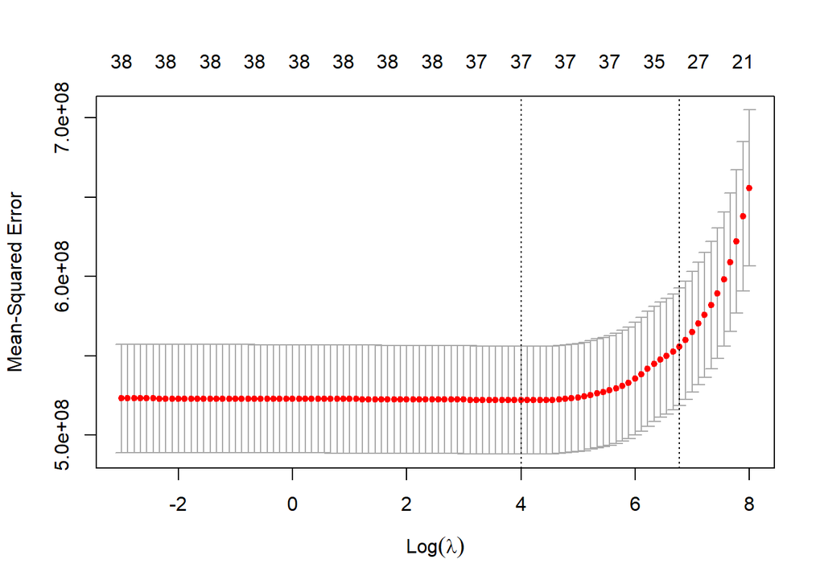

```r
plot(cv_lasso)
```

The following plot visualizes the selection of predictor variables for various values of the tuning parameter lambda.

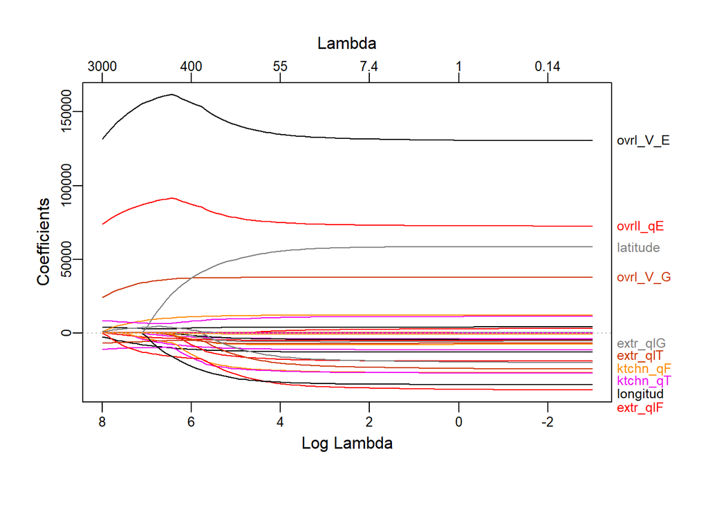

```r
plot_glmnet(cv_lasso$glmnet.fit)
```

There are a total of 40 possible coefficients in a full model including all predictors in the train dataset, including the intercept coefficient of $\beta_0$ and the dummy variables created for categorical predictors. Using the 1SE rule, resulting LASSO model eliminates 10 of these coefficients. The result is that using the 1SE rule, there are 29 predictors included in the model (including dummy variables).

```r
predict(cv_lasso, s = "lambda.1se", type = "coefficients")
```

```
## 40 x 1 sparse Matrix of class "dgCMatrix"
##                               lambda.1se
## (Intercept)                -2.012126e+06
## gr_liv_area                 5.627212e+01
## first_flr_sf                1.135041e+00
## second_flr_sf               .
## total_bsmt_sf               3.678627e+01
## low_qual_fin_sf            -2.510397e+01
## wood_deck_sf                8.205892e+00
## open_porch_sf               7.546015e+00
## bsmt_unf_sf                -1.925968e+01
## mas_vnr_area                1.428797e+01
## garage_cars                 3.064783e+03
## garage_area                 1.151206e+01
## year_built                  3.150689e+02
## tot_rms_abv_grd            -1.083998e+03
## full_bath                   .
## overall_qualAverage        -2.979647e+03
## overall_qualBelow_Average  -8.880974e+03
## overall_qualExcellent       8.977849e+04
## overall_qualFair           -5.869522e+03
## overall_qualGood            9.631508e+03
## overall_qualVery_Excellent  1.594074e+05
## overall_qualVery_Good       3.582401e+04
## kitchen_qualFair           -4.874261e+03
## kitchen_qualGood            .
## kitchen_qualTypical        -9.680261e+03
## fireplaces                  6.530112e+03
## fireplace_quFair            .
## fireplace_quGood            4.625005e+03
## fireplace_quNo_Fireplace    .
## fireplace_quPoor            .
## fireplace_quTypical         .
## exter_qualFair             -1.424651e+04
## exter_qualGood              .
## exter_qualTypical          -5.214987e+03
## lot_frontage                6.792076e+01
## lot_area                    5.527978e-01
## longitude                  -8.934165e+03
## latitude                    1.426969e+04
## misc_val                    .
## year_sold                   .
```

Now let’s find the test error.

```r
test_x = model.matrix(sale_price ~ ., test_df)[, -1]
lasso_pred = predict(cv_lasso, newx = test_x, s = "lambda.min")

lasso_mae = mean(abs(lasso_pred - test_df$sale_price))
lasso_rmse = sqrt(mean((lasso_pred - test_df$sale_price)^2))
```

## **Part (b)**

**(b) Fit an elastic net model on the training data. Report the selected tuning parameters and the test error. Is it possible to apply the 1SE rule to select the tuning parameters for elastic net? If the 1SE rule is applicable, implement it to select the tuning parameters. If not, explain why.**

```r
set.seed(2025)

ctrl = trainControl(method = "cv") # number = 10 is default for "cv" method

enet_fit = train(sale_price ~ .,
                 data = train_df,
                 method = "glmnet",
                 tuneGrid = expand.grid(alpha = seq(0, 1, length = 21),
                                        lambda = lambda_seq),
                 trControl = ctrl)

enet_fit$bestTune
```

```
##     alpha  lambda
## 186  0.05 629.197
```

In the elastic net model trained above, the tuning parameters selected for the best fit were $\alpha$ = 0.05, and $\lambda$ = 629.1970259. The plot below visualizes the process of selecting the tuning parameters.

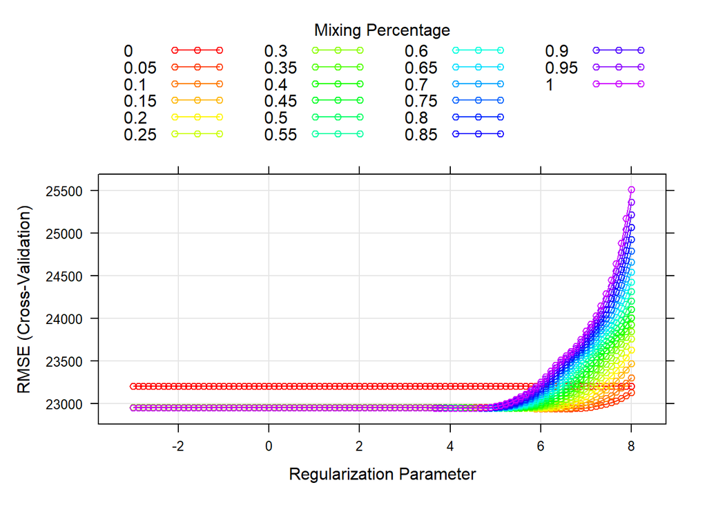

```r
myCol = rainbow(25)
myPar = list(superpose.symbol = list(col = myCol),
              superpose.line = list(col = myCol))
plot(enet_fit, par.settings = myPar, xTrans = log)
```

Here are the top 10 best tuning parameter sets, and their associated RMSE, RSquared, and some other measures of goodness of fit.

```r
enet_results = enet_fit$results |>
  as.data.frame() |>
  as_tibble() |>
  arrange(RMSE)

enet_results |>
  head(10)
```

```
## # A tibble: 10 × 8
##    alpha lambda   RMSE Rsquared    MAE RMSESD RsquaredSD MAESD
##    <dbl>  <dbl>  <dbl>    <dbl>  <dbl>  <dbl>      <dbl> <dbl>
##  1  0.05   629. 22940.    0.902 16649.  2052.     0.0165 1484.
##  2  0.05   563. 22940.    0.902 16656.  2049.     0.0164 1485.
##  3  0.05   703. 22940.    0.902 16642.  2055.     0.0165 1482.
##  4  0.05   504. 22940.    0.902 16662.  2048.     0.0164 1487.
##  5  0.05   451. 22941.    0.902 16668.  2046.     0.0164 1488.
##  6  0.1    451. 22941.    0.902 16655.  2050.     0.0164 1487.
##  7  0.1    403. 22941.    0.902 16662.  2048.     0.0164 1488.
##  8  0.05   403. 22942.    0.902 16674.  2044.     0.0164 1489.
##  9  0.05   786. 22942.    0.902 16635.  2058.     0.0165 1480.
## 10  0.1    504. 22942.    0.902 16648.  2052.     0.0164 1485.
```

```r
enet_results[1,]$MAE
```

```
## [1] 16648.91
```

```r
enet_results[1,]$RMSE
```

```
## [1] 22939.55
```

Now let’s find the test error for this model.

```r
enet_pred = predict(enet_fit, newdata = test_df, s = "lambda.min")

enet_mae = mean(abs(enet_pred - test_df$sale_price))
enet_rmse = sqrt(mean((enet_pred - test_df$sale_price)^2))
```

For the test error of the final Elastic Net fit with the best tuning parameter set, the mean absolute error is 1.5318299^{4} and the RMSE is 2.093101^{4}.

Here are the coefficients resulting from the final model selected from the best tuned parameters in the elastic net model.

```r
coef(enet_fit$finalModel, enet_fit$bestTune$lambda)
```

```
## 40 x 1 sparse Matrix of class "dgCMatrix"
##                                       s1
## (Intercept)                -5.120864e+06
## gr_liv_area                 3.870318e+01
## first_flr_sf                2.666594e+01
## second_flr_sf               2.538430e+01
## total_bsmt_sf               3.492195e+01
## low_qual_fin_sf            -1.586723e+01
## wood_deck_sf                1.234978e+01
## open_porch_sf               1.693325e+01
## bsmt_unf_sf                -2.070932e+01
## mas_vnr_area                1.174055e+01
## garage_cars                 4.040055e+03
## garage_area                 8.963021e+00
## year_built                  3.187443e+02
## tot_rms_abv_grd            -3.413695e+03
## full_bath                  -3.650739e+03
## overall_qualAverage        -5.119589e+03
## overall_qualBelow_Average  -1.269639e+04
## overall_qualExcellent       7.595284e+04
## overall_qualFair           -1.148778e+04
## overall_qualGood            1.195184e+04
## overall_qualVery_Excellent  1.366410e+05
## overall_qualVery_Good       3.761301e+04
## kitchen_qualFair           -2.350119e+04
## kitchen_qualGood           -1.593874e+04
## kitchen_qualTypical        -2.399309e+04
## fireplaces                  1.078951e+04
## fireplace_quFair           -7.865048e+03
## fireplace_quGood            1.471060e+02
## fireplace_quNo_Fireplace    1.741099e+03
## fireplace_quPoor           -5.810841e+03
## fireplace_quTypical        -6.964498e+03
## exter_qualFair             -3.271492e+04
## exter_qualGood             -1.431357e+04
## exter_qualTypical          -1.893069e+04
## lot_frontage                9.999979e+01
## lot_area                    6.029606e-01
## longitude                  -3.518692e+04
## latitude                    5.767677e+04
## misc_val                    8.643843e-01
## year_sold                  -5.702821e+02
```

**1SE**

Because this Elastic Net model was created using the `train` function from the `caret` package, it is not possible to easily apply the 1SE method to select the tuning parameters. This is because `caret` does not calculate `lambda.1se`. The `cv.glmnet()` function from thee `glmnet` package does calculate `lambda.1se`, but we have used the `caret` package here, so it is not available.

## **Part (c)**

**(c) Fit a partial least squares model on the training data and report the test error. How many components are included in your model?**

```r
set.seed(2025)
pls_fit = plsr(sale_price ~ .,
               data = train_df,
               scale = TRUE,
               validation = "CV")

summary(pls_fit)
```

```
## Data:    X dimension: 1440 39
##  Y dimension: 1440 1
## Fit method: kernelpls
## Number of components considered: 39
##
## VALIDATION: RMSEP
## Cross-validated using 10 random segments.
##        (Intercept)  1 comps  2 comps  3 comps  4 comps  5 comps  6 comps
## CV           73685    33505    27956    25043    24003    23380    23221
## adjCV        73685    33495    27920    24981    23939    23315    23160
##        7 comps  8 comps  9 comps  10 comps  11 comps  12 comps  13 comps
## CV       23097    23074    23059     23047     23031     23016     23022
## adjCV    23040    23017    23001     22988     22971     22957     22963
##        14 comps  15 comps  16 comps  17 comps  18 comps  19 comps  20 comps
## CV        23028     23034     23037     23042     23046     23057     23059
## adjCV     22968     22974     22976     22981     22985     22995     22997
##        21 comps  22 comps  23 comps  24 comps  25 comps  26 comps  27 comps
## CV        23065     23064     23065     23065     23066     23068     23070
## adjCV     23002     23001     23002     23002     23003     23005     23006
##        28 comps  29 comps  30 comps  31 comps  32 comps  33 comps  34 comps
## CV        23070     23070     23070     23070     23070     23070     23070
## adjCV     23007     23006     23006     23006     23006     23006     23006
##        35 comps  36 comps  37 comps  38 comps  39 comps
## CV        23070     23070     23070     23070     23092
## adjCV     23006     23006     23006     23006     23032
##
## TRAINING: % variance explained
##             1 comps  2 comps  3 comps  4 comps  5 comps  6 comps  7 comps
## X             20.02    25.93    29.67    33.59    37.01    40.03    42.49
## sale_price    79.73    86.35    89.36    90.37    90.87    90.99    91.06
##             8 comps  9 comps  10 comps  11 comps  12 comps  13 comps  14 comps
## X             45.53    47.97     50.15     52.01     53.69     55.35     56.86
## sale_price    91.08    91.10     91.13     91.15     91.15     91.16     91.16
##             15 comps  16 comps  17 comps  18 comps  19 comps  20 comps
## X              58.64     60.01     62.18     63.87     65.26     67.10
## sale_price     91.16     91.16     91.16     91.16     91.16     91.16
##             21 comps  22 comps  23 comps  24 comps  25 comps  26 comps
## X              68.44     70.12     71.72     73.35     75.20     77.27
## sale_price     91.16     91.16     91.16     91.16     91.16     91.16
##             27 comps  28 comps  29 comps  30 comps  31 comps  32 comps
## X              78.97     80.10     81.83     83.55     84.39     86.34
## sale_price     91.16     91.16     91.16     91.16     91.16     91.16
##             33 comps  34 comps  35 comps  36 comps  37 comps  38 comps
## X              88.63     90.79     92.79     95.45     97.49    100.00
## sale_price     91.16     91.16     91.16     91.16     91.16     91.16
##             39 comps
## X             100.67
## sale_price     91.16
```

The following plot visualizes the process of selecting the number of components.

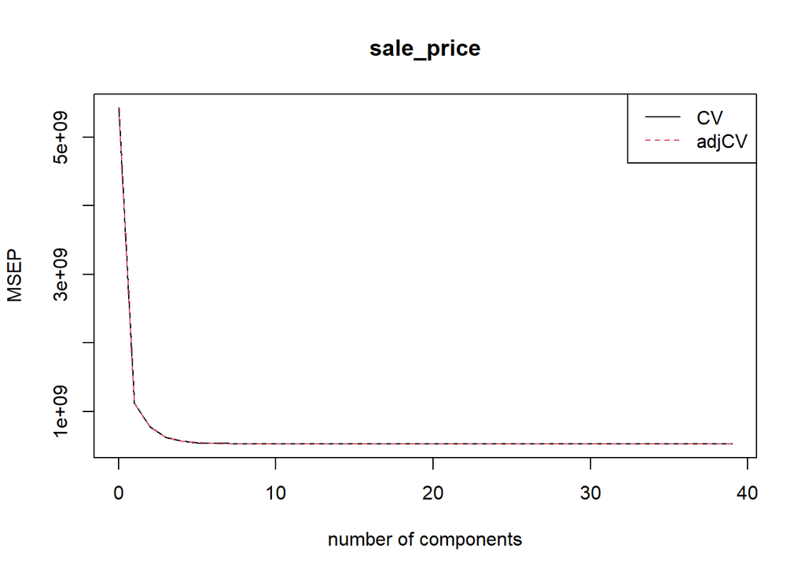

```r
validationplot(pls_fit, val.type = "MSEP", legendpos = "topright")
```

Let us see the optimal number of components.

```r
cv_mse = RMSEP(pls_fit)
ncomp_cv = which.min(cv_mse$val[1,,])
ncomp_cv
```

```
## 12 comps
##       13
```

Now let’s calculate the test error.

```r
test_x = model.matrix(sale_price ~ ., test_df)[, -1]
pls_pred = predict(pls_fit, newdata = test_df, ncomp = ncomp_cv)

pls_mae = mean(abs(pls_pred - test_df$sale_price))
pls_rmse = sqrt(mean((pls_pred - test_df$sale_price)^2))
```

For the test error of the final PLS fit with the best tuning parameter set, the mean absolute error is 1.555155^{4} and the RMSE is 2.1183421^{4}.

## **Part (d)**

**(d) Choose the best model for predicting the response and explain your choice.**

```r
compare_models_df = tibble(
    Model = c("Lasso", "Elastic Net", "PLS"),
    MAE = c(lasso_mae, enet_mae, pls_mae),
    RMSE = c(lasso_rmse, enet_rmse, pls_rmse)
  ) |>
  arrange(RMSE)

compare_models_df |>
  knitr::kable(digits = 2)
```

| Model | MAE | RMSE |
| --- | --- | --- |
| Elastic Net | 15318.30 | 20931.01 |
| Lasso | 15396.05 | 21002.41 |
| PLS | 15551.55 | 21183.42 |

Based on these results, we can see that the Elastic Net model has the best MAE and RMSE, which means that it has the fewest large errors. Therefore, I choose the Elastic Net model because it has the lowest errors.

## **Part (e)**

**(e) If R package “caret” was used for the lasso in (a), retrain this model using R package “glmnet”, and vice versa. Compare the selected tuning parameters between the two software approaches. Should there be discrepancies in the chosen parameters, discuss potential reasons for these differences.**

Since I used the `glmnet` package in part (a), I will use the `caret` package here.

```r
set.seed(2025)
lasso_fit = train(sale_price ~ .,
  data = train_df,
  method = "glmnet",
  tuneGrid = expand.grid(alpha = 1,
                        lambda = lambda_seq),
  trControl = ctrl)
```

The `caret` model has selected $\lambda$ = 68.1848379 as the tuning parameter. Recall that the `glmnet` model had selected 54.59815 as the `lambda.min`.

```r
lasso_fit$bestTune$lambda
```

```
## [1] 68.18484
```